# Reinforcement Learning

Abe Vos

Mei 2022

# Vorige keer

## Markov Decision Process

- Statenruimte $\mathcal{S}$
- Acties $\mathcal{A}_s, \forall s\in\mathcal{S}$
- Overgangsfunctie $p(S_{t+1}=s'|S_t=s,A_t=a)$
- Beloningsfunctie $R(s, a, s')$

## Policy/Value Iteration

- Bereken de waardefunctie
  - Verwachte totale beloning voor iedere staat
- Update beleid met waardefunctie
  - Kies de actie die naar de meest “waardevolle” staat leidt
- Maak gebruik van de overgangsfunctie

## Volgende stappen

- Overgangsfunctie/beloningsfunctie niet beschikbaar
- Leer van ervaringen uit de omgeving

# Monte Carlo Methodes

[figure not shown]

Patience

## Schatten door simulatie

- Schudt de kaarten
- Probeer het spel uit te spelen
- Herhaal een paar duizend keer

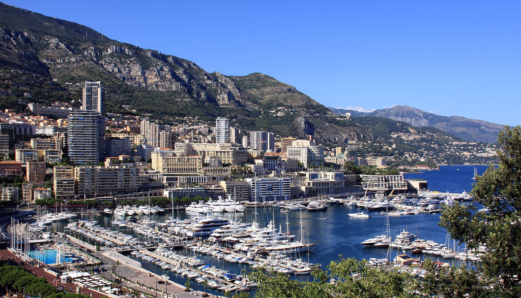

Monte Carlo, Monaco

## Omgekeerde probleem van kansrekening

- Kansrekening: Gebruik deterministische methodes voor stochastische problemen
- Monte Carlo: Gebruik stochastische methodes voor deterministisch problemen

## Voorbeeld: Bereken $\pi$

- Eenheidscirkel
  - Straal $r=1$
- Oppervlakte $A=\pi=4\int_0^1\sqrt(1-x^2)dx$

## Monte Carlo Integration

- Bereken een integraal $I=\int f(x)dx$ binnen een volume $V$
- Neem steekproeven $x_1, x_2, \cdots, x_N$
  - Uniform verdeelt in $V$
- $I\approx V\frac{1}{N}\sum_{n=1}^N f(x_n)$

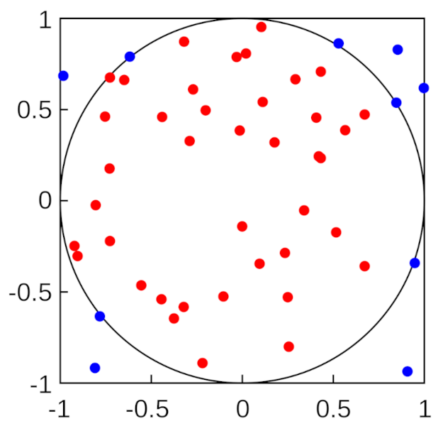

50 steekproeven in een vierkant

Schat $\pi$

- $f(x)=1$ als $x$ binnen cirkel ligt, anders $f(x)=0$
- Eenheidscirkel past in vierkant met oppervlakte 4
- 40 van de 50 punten binnen cirkel
- $4 \frac{1}{50} 40=3.2\approx\pi$
- Meer simulaties geeft betere schattingen

Verwachte waarde

- $X$ is som van twee dobbelstenen
- Verwachte waarde $\mathbb{E}[X]=\sum_{x\in\mathcal{X}}xp(X=X)$
  - Voor continue stochasten $\mathbb{E}[X]=\int_{-\infty}^{\infty} xp(X=x)dx$
- $p(X=x)$ is onbekend, gebruik Monte Carlo
  - Neem $N$ steekproeven
  - $\mathbb{E}[X]\approx\frac{1}{N}\sum_{n=1}^N x_n$

Voorbeeld: Verwachte waarde van twee dobbelstenen

```python
>>> import random
>>> N = 10000
>>> total = 0.0
>>> for n in range(N):
..      die_1 = random.randint(1, 6)
..      die_2 = random.randint(1, 6)
..      total += die_1 + die_2
>>> result = total / N
>>> print(result)
7.0029
```

Monte Carlo voor RL

- Policy Evaluation update
  - $V(s)\leftarrow\sum_{s',r}p(s',r\vert s,\pi(s))[r+\gamma V(s')]$
  - Verwachte toekomstige beloning op staat $s$
- Overgangsfunctie is niet beschikbaar
- Gebruik simulaties van beleid $\pi$ in omgeving voor Monte Carlo

Monte Carlo Prediction

- Genereer een episode: $S_0,A_0,R_1,S_1,A_1,R_2,\cdots,S_{T-1},A_{T-1},R_T$
- Van achter naar voren, bereken: $G_t=R_{t+1}+\gamma R_{t+2}+\cdots+\gamma^{T=1}R_T$
  - Dit is de beloning voor staat $S_t$
- Met $S_t$ en $G_t$, update:
  - Tel hoe vaak deze staat is bezocht $N(S_t)\leftarrow N(S_t)+1$
  - De geschatte waardefunctie $V(S_t)\leftarrow V(S_t)+\frac{1}{N(S_t)}(G_t-V(S_t))$
- Optioneel: update $V(S_t)$ alleen wanneer $S_t$ voor het *eerst* in de episode verschijnt
- Herhaal voor veel episodes

Toenemend gemiddelde

- Voor een reeks waardes $x_1, x_2, \cdots, x_T$, bereken gemiddelde na $k$ waardes te hebben gezien
  - $\mu_k=\frac{1}{k}\sum_{j=1}^k x_j$
  - Gemiddelde wordt opnieuw berekend voor elke $k$
- Update gemiddelde $\mu_{k-1}$ met $x_k$:
  - $\mu_{k-1}+\frac{1}{k}(x_k-\mu_{k-1})$
- MC Prediction update de schatting van de verwachte/gemiddelde totale beloning

Monte Carlo Methodes

- Levert optimale schatting van waardefunctie op
  - Net als Policy Evaluation
- Heeft geen dynamieken van de MDP nodig
  - *Model-free*

Tekortkomingen

- MC heeft hoge variantie
  - “Gemiddelde afwijking van het gemiddelde”
  - Meer simulaties nodig voor precieze schattingen
- MC Methodes zijn offline
  - Waardefunctie/beleid krijgt update aan eind van episode
  - Lange episodes $\rightarrow$ traag leren

# Temporal Difference Learning

Temporal-Difference Learning

- Lijkt op MC
  - Leert van ervaring
  - Model-free
- Maar heeft extra voordelen:
  - Online learning
  - Leert van onvolledige episodes

TD(0)

- Gegeven een staat $S_t$ en actie $A_t$, observeer beloning $R_{t+1}$
- Bereken de update: $V(S_t)\leftarrow V(S_t)+\alpha(R_{t+1}+\gamma V(S_{t+1}) - V(S_t))$
  - TD target: $R_{t+1}+\gamma V(S_{t+1})$
  - TD error: $\delta_t=R_{t+1}+\gamma V(S_{t+1})-V(S_t)$

Target

- MC update: $V(S_t)\leftarrow V(S_t)+\frac{1}{N(S_t)}(G_t-V(S_t))$
- TD(0) update: $V(S_t)\leftarrow V(S_t)+\alpha(R_{t+1}+\gamma V(S_{t+1})-V(S_t))$
- TD(0) gebruikt *schatting* van $G_t$ als target
  - Bootstrapping

Bias/Variance

- $G_t=R_{t+1}+\gamma R_{t+2}+\cdots+\gamma^{T-1}R_T$ is een *unbiased* schatting van $v_\pi(S_t)$
  - Hoe meer episodes $\rightarrow$ hoe preciezer de schatting
- De ‘echte’ TD target $R_{t+1}+\gamma v_\pi(S_{t+1})$ is een *unbiased* schatting van $v_\pi(S_t)$
  - We willen $v_\pi(S_t)$ schatten, dus we hebben de echte waardefunctie nog niet
- TD target $R_{t+1}+\gamma V(S_{t+1})$ is een *biased* schatting van $v_\pi(S_t)$
  - Ongeacht het aantal episodes, we gaan altijd afwijken van de ware waardefunctie

Bias/Variance (2)

- $G_t$ is afhankelijk van *alle* acties, overgangen en beloningen in de episode
  - Kan veel verschillende waarden aannemen
  - Hoge variantie
- TD target is afhankelijk van 1 actie, overgang en beloning
  - Kan minder mogelijke waarden aannemen gegeven de huidige staat en actie
  - Lagere variantie

Monte Carlo vs Temporal Difference

- MC heeft hoge variantie, geen bias
  - Erg stabiel (convergeert ook goed met functie-benadering)
  - Niet afhankelijk van Markov eigenschap
- TD heeft lage variantie, wel bias
  - Vaak efficienter dan Monte Carlo
  - TD(0) convergeert naar $v_\pi(s)$ (maar niet altijd met functie-benadering)
  - Afhankelijk van Markov eigenschap

n-Step TD

- Monte Carlo gebruikt alle stappen in een episode
  - $G_t^{(\infty)}=R_{t+1}+\gamma R_{t+2}+\cdots+\gamma^{T-1} R_T$
- TD(0) gebruikt een enkele stap
  - $G_t^{(1)}=R_{t+1}+\gamma V(S_{t+1})$
- We kunnen ook $n$ stappen gebruiken:
  - $G_t^{(n)}=R_{t+1}+\gamma R_{t+2}+\cdots+\gamma^{n-1}R_{t+n}+\gamma^n V(S_{t+n})$
  - $V(S_t)\leftarrow V(S_t)+\alpha(G_t^{(n)}-V(S_t))$

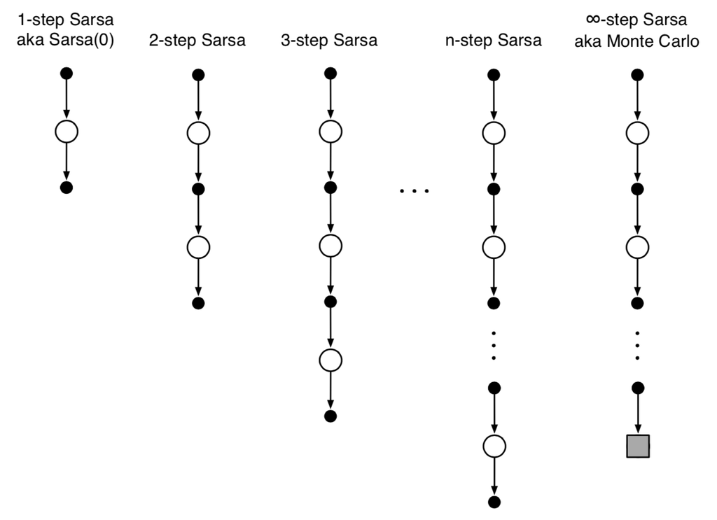

n-step TD

## TD($\lambda$)

- Combineer $G_t^{(n)}$ voor alle $n$
  - $G_t^\lambda=(1-\lambda)\sum_{n=1}^\infty\lambda^{n-1}G_t^{(n)}$
- Invloed van toekomstige stappen op heden:
  - Gewicht $(1-\lambda)\lambda^{n-1}$ wordt kleiner als $n\rightarrow\infty$
  - $0\leq\lambda\leq1$
  - $1-\lambda$ zorgt dat alle gewichten optellen naar $1$
- Forward-view TD($\lambda$)
  - $V(S_t)\leftarrow V(S_t)+\alpha(G_t^\lambda-V(S_t))$

Eligibility Traces

- Aan welke bezochte staten moeten we waarde toeschrijven?
- Frequentie heuristiek: schrijf waarde toe aan veelbezochte staten
- Recentheid heuristiek: schrijf waarde toe aan recente staten
- Eligibility Traces combineren beide heuristieken:
  - $E_0(s)=0$
  - $E_t(s)=\gamma\lambda E_{t-1}(s)+\mathbb{I}(S_t=s)$

- Gedurende elke tijdstap $t$, houd een Eligibility Trace bij voor elke staat $s\in\mathcal{S}$
- Update $V(s)$ voor elke staat $s$
  - $\delta_t=R_{t+1}+\gamma V(S_{t+1})-V(S_t)$
  - $V(s)\leftarrow V(s)+\alpha\delta_t E_t(s)$
- $E_t(s)=0$ zolang we $s$ niet hebben gezien

# Model-Free Control

Control in MDP

- Policy Iteration
  - Evalueer $V(s)$ a.d.h.v. $\pi(s)$
  - Verbeter $\pi(s)$ met $V(s)$
- Policy improvement heeft MDP model nodig
  - $\pi'(s)=\arg\max_a \sum_{s',r}p(s',r\vert s,a)[r+\gamma V(s')]$
- Gebruik een kwaliteitsfunctie $Q(s,a)$
  - Schat waarde voor elk staat/actie paar
  - Policy Improvement is model-free: $\pi'(s)=\arg\max_a Q(s,a)$

## $\varepsilon$-Greedy Policy

- We willen blijven ontdekken
  - Exploration vs. exploitation
- Neem uniforme steekproef tussen 0 en 1: $x$
- Als $x\leq\varepsilon$ kies een willekeurige actie
- Anders kies actie $a^*=\arg\max_{a}Q(s,a)$

Sarsa

Q-learning